# ANOVA, and contingency tables

Peter Ralph

# ANOVA

## Metric data from groups

Suppose we have numerical observations coming from $m$ different groups. We’d like to know how different the means are between groups, compared to variation within groups.

*For example:* dry leaf mass after 10d of growth of $k=5$ genotypes in in $m=4$ different conditions. (data here)

Dry leaf mass after 10d of growth of $k=5$ genotypes in in $m=4$ different conditions.

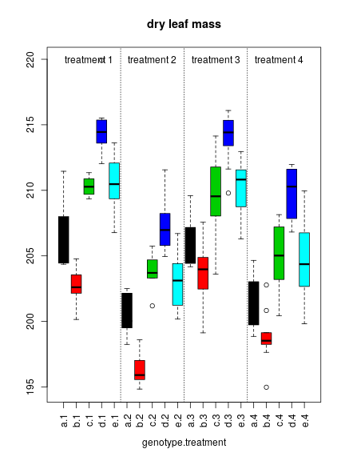

```r
leafs <- read.table("leaf_mass.tsv",
                    header=TRUE)
boxplot(y ~ geno + treat,
        main='dry leaf mass',
        xlab='genotype.treatment',
        data=leafs)
```

1. Make the model.
2. What posterior(s) will we look at?

[figure not shown]

## a stan model

```r
anova_model <- stan_model(model_code="
data {
    int N;
    int ngeno;
    int ntreat;
    vector[N] leaf;
    int geno[N];
    int treat[N];
}
parameters {
    real mu;
    vector[ngeno] alpha;
    vector[ntreat] beta;
    matrix[ngeno, ntreat] gamma;
    matrix<lower=0>[ngeno, ntreat] sigma;
    real<lower=0> sigma_gamma;
}
model {
    vector[N] muvec;
    vector[N] sigmavec;
    muvec = mu + alpha[geno] + beta[treat];
    for (k in 1:N) {
        muvec[k] += sigma_gamma * gamma[geno[k], treat[k]];
        sigmavec[k] = sigma[geno[k], treat[k]];
    }
    leaf ~ normal(muvec, sigmavec);
    // DOESN'T WORK: leaf ~ normal(muvec, sigma[geno, treat]);
    mu ~ normal(205, 10);
    alpha ~ normal(0, 10);
    beta ~ normal(0, 10);
    for (k in 1:ngeno) {
        // using Matt's trick here
        gamma[k] ~ normal(0, 1);
        sigma[k] ~ gamma(20, 10);
    }
    sigma_gamma ~ gamma(0.5, 0.5);
}
")
```

```r
fit <- sampling(anova_model,
            data=list(N=nrow(leafs),
                      ngeno=ngeno,
                      ntreat=ntreat,
                      leaf=leafs$y,
                      geno=as.numeric(leafs$geno),
                      treat=as.numeric(leafs$treat)))
```

```r
print(fit)
```

```
## Inference for Stan model: 585d0bae0af15bb83752f81372fca2b7.
## 4 chains, each with iter=2000; warmup=1000; thin=1;
## post-warmup draws per chain=1000, total post-warmup draws=4000.
##
##                mean se_mean   sd    2.5%     25%     50%     75%   97.5%
## mu           205.53    0.16 5.58  194.69  201.60  205.64  209.30  216.46
## alpha[1]      -2.15    0.12 4.19  -10.27   -4.93   -2.26    0.65    6.32
## alpha[2]      -5.46    0.12 4.19  -13.58   -8.27   -5.57   -2.69    2.91
## alpha[3]       1.26    0.12 4.19   -6.88   -1.55    1.15    4.05    9.70
## alpha[4]       5.58    0.12 4.19   -2.54    2.73    5.47    8.33   13.96
## alpha[5]       1.39    0.12 4.18   -6.77   -1.44    1.31    4.11    9.76
## beta[1]        3.29    0.13 4.56   -5.50    0.11    3.32    6.34   12.14
## beta[2]       -3.53    0.13 4.56  -12.28   -6.67   -3.51   -0.43    5.37
## beta[3]        3.10    0.13 4.56   -5.66   -0.03    3.15    6.20   11.89
## beta[4]       -1.75    0.13 4.56  -10.53   -4.91   -1.74    1.30    7.08
## gamma[1,1]     0.03    0.01 0.98   -1.89   -0.65    0.04    0.69    1.97
## gamma[1,2]     0.18    0.01 1.03   -1.85   -0.54    0.18    0.89    2.18
## gamma[1,3]    -0.13    0.01 1.00   -2.05   -0.81   -0.15    0.53    1.88
## gamma[1,4]    -0.03    0.01 0.98   -1.99   -0.69   -0.02    0.66    1.90
## gamma[2,1]    -0.32    0.01 1.01   -2.26   -1.01   -0.33    0.37    1.65
## gamma[2,2]    -0.06    0.01 0.97   -1.95   -0.72   -0.08    0.60    1.86
## gamma[2,3]     0.23    0.01 0.97   -1.70   -0.42    0.22    0.88    2.10
## gamma[2,4]     0.13    0.01 0.96   -1.74   -0.54    0.14    0.78    1.99
## gamma[3,1]     0.08    0.01 0.97   -1.83   -0.57    0.07    0.76    1.97
## gamma[3,2]     0.07    0.02 0.99   -1.94   -0.59    0.06    0.73    2.07
## gamma[3,3]    -0.08    0.01 0.97   -1.91   -0.72   -0.11    0.56    1.85
## gamma[3,4]    -0.06    0.01 0.94   -1.91   -0.69   -0.05    0.57    1.76
## gamma[4,1]     0.11    0.01 0.98   -1.84   -0.53    0.11    0.78    2.01
## gamma[4,2]    -0.14    0.01 0.98   -2.07   -0.77   -0.14    0.52    1.77
## gamma[4,3]    -0.08    0.01 0.96   -1.96   -0.73   -0.08    0.56    1.88
## gamma[4,4]     0.10    0.01 0.94   -1.75   -0.55    0.10    0.76    1.90
## gamma[5,1]     0.15    0.01 0.99   -1.82   -0.49    0.15    0.80    2.14
## gamma[5,2]    -0.12    0.01 0.98   -2.02   -0.81   -0.13    0.54    1.82
## gamma[5,3]     0.07    0.01 0.94   -1.78   -0.56    0.07    0.72    1.90
## gamma[5,4]    -0.12    0.02 1.02   -2.10   -0.83   -0.13    0.57    1.87
## sigma[1,1]     2.11    0.00 0.33    1.54    1.88    2.08    2.31    2.85
## sigma[1,2]     1.93    0.01 0.35    1.34    1.68    1.91    2.14    2.70
## sigma[1,3]     2.06    0.00 0.34    1.48    1.81    2.03    2.27    2.80
## sigma[1,4]     2.07    0.00 0.31    1.53    1.85    2.04    2.25    2.78
## sigma[2,1]     1.78    0.00 0.32    1.25    1.55    1.75    1.98    2.50
```

[output cut: 60 more lines]

```
## sigma[4,1]   4652    1
## sigma[4,2]   4516    1
## sigma[4,3]   5362    1
## sigma[4,4]   5103    1
## sigma[5,1]   4977    1
## sigma[5,2]   5359    1
## sigma[5,3]   5076    1
## sigma[5,4]   5091    1
## sigma_gamma  2364    1
## lp__         1666    1
##
## Samples were drawn using NUTS(diag_e) at Thu Jan 24 23:29:11 2019.
## For each parameter, n_eff is a crude measure of effective sample size,
## and Rhat is the potential scale reduction factor on split chains (at
## convergence, Rhat=1).
```

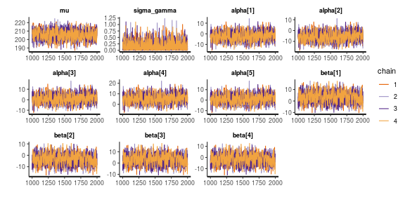

```r
stan_trace(fit, pars=c("mu", "sigma_gamma", "alpha", "beta"))
```

```
## ci_level: 0.8 (80% intervals)
```

```
## outer_level: 0.95 (95% intervals)
```

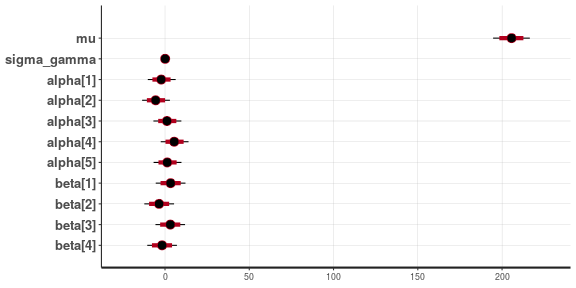

```r
stan_plot(fit, pars=c("mu", "sigma_gamma", "alpha", "beta"))
```

[figure not shown]

```r
stan_trace(fit, pars=c("gamma", "sigma"))
```

```r
samples <- extract(fit)

# let's get the posterior distribution of
# the group mean for (genotype a, treatment 1)

samples <- extract(fit)

post_a1 <- samples$mu + samples$alpha[,1] + samples$beta[,1] + samples$gamma[,1,1]

post_means <- as.vector(samples$mu) + samples$gamma
for (k in 1:ngeno) {
    post_means[,k,] <- post_means[,k,] + samples$alpha[,k]
}
for (k in 1:ntreat) {
    post_means[,,k] <- post_means[,,k] + samples$beta[,k]
}

dim(post_means) <- c(dim(post_means)[1], prod(dim(post_means)[2:3]))
colnames(post_means) <- outer(levels(leafs$geno), levels(leafs$treat), paste, sep=".")
post_means <- as.data.frame(post_means)
```

# Stochastic minute

## The Dirichlet distribution

A collection of $n$ nonnegative random numbers $(P_1, \ldots, P_n)$ *that sums to 1* has a **Dirichlet($\alpha_1, \ldots, \alpha_n$)** distribution if it has probability density
$$\frac{1}{B(\alpha)} \prod_{i=1}^n p_i^{\alpha_i - 1} .$$

*Facts:*

1. If $U \sim \Beta(\alpha, \beta)$ then $(U, 1-U) \sim \Dirichlet(\alpha, \beta)$.
2. If $Y_1, \ldots, Y_n$ are independent, Exponential with rates $\alpha_1, \ldots, \alpha_n$ then
   $$Y / \sum_{i=1}^n Y_i \sim \Dirichlet(\alpha_1, \ldots, \alpha_n) .$$
3. Useful? Yes, if you need a distribution on numbers that sum to one (e.g., class proportions).

## Exercise

Simulate from a

- $\Dirichlet(1, 1, 1)$
- $\Dirichlet(100, 100, 100)$

and describe the difference. *(Hint: plot these in the $(P_1, P_2)$ plane.)*

# Categorical data

## Hair and Eye color

```r
data(HairEyeColor)
```

[output not shown]

```
## , , Sex = Male
##
##        Eye
## Hair    Brown Blue Hazel Green
##   Black    32   11    10     3
##   Brown    53   50    25    15
##   Red      10   10     7     7
##   Blond     3   30     5     8
##
## , , Sex = Female
##
##        Eye
## Hair    Brown Blue Hazel Green
##   Black    36    9     5     2
##   Brown    66   34    29    14
##   Red      16    7     7     7
##   Blond     4   64     5     8
```

```r
(haireye <- data.frame(hair = dimnames(HairEyeColor)[[1]][slice.index(HairEyeColor, 1)],
                      eye = dimnames(HairEyeColor)[[2]][slice.index(HairEyeColor, 2)],
                      sex = dimnames(HairEyeColor)[[3]][slice.index(HairEyeColor, 3)],
                      number = HairEyeColor))
```

```
##     hair   eye    sex number.Hair number.Eye number.Sex number.Freq
## 1  Black Brown   Male       Black      Brown       Male          32
## 2  Brown Brown   Male       Brown      Brown       Male          53
## 3    Red Brown   Male         Red      Brown       Male          10
## 4  Blond Brown   Male       Blond      Brown       Male           3
## 5  Black  Blue   Male       Black       Blue       Male          11
## 6  Brown  Blue   Male       Brown       Blue       Male          50
## 7    Red  Blue   Male         Red       Blue       Male          10
## 8  Blond  Blue   Male       Blond       Blue       Male          30
## 9  Black Hazel   Male       Black      Hazel       Male          10
## 10 Brown Hazel   Male       Brown      Hazel       Male          25
## 11   Red Hazel   Male         Red      Hazel       Male           7
## 12 Blond Hazel   Male       Blond      Hazel       Male           5
## 13 Black Green   Male       Black      Green       Male           3
## 14 Brown Green   Male       Brown      Green       Male          15
```

[output cut: 18 more lines]

*Questions:*

1. Are hair and eye color independent in this sample?
2. Do hair and eye color proportions differ by sex?

## Independence and multiplicativity

If hair and eye color are *independent*, then probabilities of combinations are *multiplicative*:
$$\begin{aligned}
\P\{\text{black hair and blue eyes}\} \\
&\qquad =
\P\{\text{black hair}\} \times \P\{\text{blue eyes}\given\text{black hair}\} \\
\end{aligned}$$

which by independence is
$$\begin{aligned}
&\qquad =
\P\{\text{black hair}\} \times \P\{\text{blue eyes}\}
\end{aligned}$$

## Multiplicativity to additivity

A model of *independence* will have a *multiplicative* form:
$$p_{ab} = p_a \times p_b .$$

Set $\lambda = \log(p)$, so that
$$\lambda_{ab} = \lambda_a + \lambda_b .$$

# Stochastic facts

## Poisson additivity

If we have Poisson-many things of two categories:
$$\begin{aligned}
A &\sim \Poisson(a) \\
B &\sim \Poisson(b)
\end{aligned}$$
then the total number of things is also Poisson:
$$A + B \sim \Poisson(a + b)$$
and each thing chooses its type independently:
$$A \given A + B \sim \Binom\left(A+B, \frac{a}{a+b}\right) .$$

# Back to hair and eye colors

## A model

For hair color $i$ and eye color $j$, the number of students with that combination is
$$N_{ij} \sim \Poisson(\mu_{ij}) .$$

If hair and eye color are independent of each other and of sex, then
$$\begin{aligned}
\mu_{ij}
&=
\exp\left( \alpha_i + \beta_j \right) .
\end{aligned}$$

## Nonindependence?

$$\begin{aligned}
\mu_{ij}
&=
\exp\left( \alpha_i + \beta_j + \gamma_{ij} \right) ?
\end{aligned}$$

Is this identifiable?

## Nonindependence.

$$\begin{aligned}
\mu_{ij} &= \exp\left( \delta_{ij} \right) \\
\delta_{ij} &\sim \Normal( \alpha_i + \beta_j, \sigma)
\end{aligned}$$

*Pick appropriate priors.*